# Measuring Social Vulnerability by Using Factor and Cluster Analysis

Ronny Goei

2022-12-04

# 1 Preface

## 1.1 Pendahuluan

Pandemi COVID-19 merupakan bentuk bahaya yang memiliki potensi mengancam segala aspek kehidupan masyarakat seperti sosial, kesehatan, dan psikologis. Dampak pada masyarakat Indonesia tidak berbeda jauh dengan negara lain yang juga mengalami COVID 19. Kondisi kerentanan sosial menjadi realitas nyata yang terjadi pada masyarakat dalam menghadapi pandemi COVID-19.

Di era pemulihan ekonomi ini, kerentanan dapat dipandang dari dua arah. Dimana sisi positif kerentanan ini dapat kita pandang sebagai suatu masalah yang dapat diselesaikan dalam ranah pihak CSR. Di sinilah peran industri untuk pro aktif dalam mencari peluang dengan memanfaatkan kerentanan yang ditimbulkan oleh COVID-19. Sementara sisi lainnya, kerentanan ini dapat kita pandang sebagai permasalahan yang disebabkan oleh berbagai aspek yang diakibatkan oleh COVID-19, sehingga dapat ditanggulangi dengan mengintegrasikan perencanaan penanggulangan resiko dengan program pengembangan lainnya.

## 1.2 Library dan Setup

```r
#data cleaning
library(dplyr)
library(readxl) # untuk membaca data excel
library(readr) # untuk membaca data
library(tidyverse) # untuk data manipulation
library(stringr) # untuk persiapan data

#data analysis
library(GGally) # untuk membuat matriks korelasi
library(psych) # untuk melakukan analisis KMO
library(GPArotation) # untuk melakukan factor analysis
library(factoextra) # untuk mengekstrak dan visualisasi Hasil analisis data multivariat
library(BAMMtools) # untuk membuat natural breaks pada pemetaan
library(ppclust) # untuk membuat Probabilistic and Possibilistic Cluster Analysis

#data visualization
library(gridExtra) # untuk membuat mixed plot dalam satu hasil
library(leaflet) # untuk visualisasi interaktif
```

## 1.3 Dataset

Berikut adalah daftar kecamatan dengan informasi detail demografi penduduk yang juga meliputi ketersediaan Rumah Sakit dan jumlah penderita Covid.

```r
covid <- readxl::read_xlsx("dataset/covid_LBB.xlsx")
head(covid)
```

| Kecamatan | lansia | disabilitas | kepadatan_penduduk | penduduk_nonmuslim | pendidikan_rendah | RS_covid | rasio_ketergantungan | WNA | RS | tenaga_kesehatan | apotek | puskesmas | balita | positif_cov | rawat_cov | isoman_cov |
| --- | --- | --- | --- | --- | --- | --- | --- | --- | --- | --- | --- | --- | --- | --- | --- | --- |
| CAKUNG | 6.217495 | 0.03013983 | 96231 | 8.755384 | 0.3984311 | 1 | 35.00000 | 0.005758871 | 1 | 1503 | 62 | 9 | 4.285196 | 11740 | 82 | 102 |
| CEMPAKA PUTIH | 10.852327 | 0.01034276 | 71886 | 13.638986 | 0.2939110 | 5 | 39.66667 | 0.053748730 | 2 | 2027 | 47 | 4 | 7.437936 | 4998 | 50 | 17 |
| CENGKARENG | 6.585898 | 0.14911626 | 124663 | 19.556382 | 0.4557412 | 1 | 39.16667 | 0.018045530 | 1 | 2038 | 121 | 10 | 3.815583 | 13036 | 109 | 146 |
| CILANDAK | 9.310706 | 0.02100348 | 64898 | 9.773135 | 0.3270238 | 2 | 38.40000 | 0.129418856 | 3 | 1414 | 39 | 6 | 5.903733 | 8201 | 62 | 114 |
| CILINCING | 5.975218 | 0.01451552 | 134303 | 8.349631 | 0.4765231 | 3 | 43.00000 | 0.002725743 | 1 | 1396 | 64 | 10 | 5.542494 | 7899 | 73 | 63 |
| CIPAYUNG | 7.000645 | 0.38417211 | 84663 | 10.500796 | 0.3480075 | 1 | 39.75000 | 0.004460778 | 0 | 1399 | 56 | 11 | 7.355121 | 10437 | 63 | 124 |

# 2 Preprocess

> Cleansing & Exploratory Data Analysis

Memastikan tidak adanya data NA dan Null value

```r
anyNA(covid)
```

```
## [1] FALSE
```

```r
is.null(covid)
```

```
## [1] FALSE
```

```r
colSums(is.na(covid))
```

```
##            Kecamatan               lansia          disabilitas
##                    0                    0                    0
##   kepadatan_penduduk   penduduk_nonmuslim    pendidikan_rendah
##                    0                    0                    0
##             RS_covid rasio_ketergantungan                  WNA
##                    0                    0                    0
##                   RS     tenaga_kesehatan               apotek
##                    0                    0                    0
##            puskesmas               balita          positif_cov
##                    0                    0                    0
##            rawat_cov           isoman_cov
##                    0                    0
```

```r
anyDuplicated(covid)
```

```
## [1] 0
```

- Tidak ada data NA dan Duplikat

```r
summary(covid)
```

```
##   Kecamatan             lansia        disabilitas      kepadatan_penduduk
##  Length:44          Min.   : 5.873   Min.   :0.01019   Min.   : 11877
##  Class :character   1st Qu.: 7.844   1st Qu.:0.02388   1st Qu.: 87832
##  Mode  :character   Median : 8.845   Median :0.03287   Median :123268
##                     Mean   : 8.997   Mean   :0.05443   Mean   :144509
##                     3rd Qu.: 9.776   3rd Qu.:0.04140   3rd Qu.:167995
##                     Max.   :13.219   Max.   :0.38417   Max.   :596126
##  penduduk_nonmuslim pendidikan_rendah    RS_covid     rasio_ketergantungan
##  Min.   : 0.04063   Min.   :0.2687    Min.   :0.000   Min.   :35.00
##  1st Qu.: 9.05234   1st Qu.:0.3334    1st Qu.:1.000   1st Qu.:39.26
##  Median :12.11404   Median :0.3501    Median :2.000   Median :39.77
##  Mean   :16.59378   Mean   :0.3751    Mean   :2.159   Mean   :39.89
##  3rd Qu.:19.81415   3rd Qu.:0.4014    3rd Qu.:3.000   3rd Qu.:40.36
##  Max.   :50.68831   Max.   :0.5982    Max.   :5.000   Max.   :47.33
##       WNA                 RS        tenaga_kesehatan     apotek
##  Min.   :0.000000   Min.   :0.000   Min.   : 100     Min.   :  0.00
##  1st Qu.:0.007346   1st Qu.:1.000   1st Qu.:1251     1st Qu.: 39.00
##  Median :0.035313   Median :1.500   Median :1433     Median : 48.00
##  Mean   :0.049053   Mean   :1.818   Mean   :1434     Mean   : 52.27
##  3rd Qu.:0.068665   3rd Qu.:3.000   3rd Qu.:1614     3rd Qu.: 64.75
##  Max.   :0.206289   Max.   :7.000   Max.   :2906     Max.   :121.00
##    puskesmas         balita        positif_cov      rawat_cov
##  Min.   : 3.00   Min.   : 3.816   Min.   :  242   Min.   :  0.00
##  1st Qu.: 6.00   1st Qu.: 5.583   1st Qu.: 5698   1st Qu.: 49.75
##  Median : 7.50   Median : 6.496   Median : 7966   Median : 62.50
##  Mean   : 7.75   Mean   : 9.139   Mean   : 7587   Mean   : 65.61
##  3rd Qu.: 9.25   3rd Qu.: 8.814   3rd Qu.: 9622   3rd Qu.: 77.00
##  Max.   :14.00   Max.   :51.532   Max.   :14329   Max.   :142.00
##    isoman_cov
##  Min.   :  0.00
##  1st Qu.: 41.75
##  Median : 62.50
##  Mean   : 67.93
##  3rd Qu.: 88.50
##  Max.   :175.00
```

**Insight**: Berdasarkan hasil `summary(covid)`:

- Rerata presentasi penduduk lansia untuk masing masing kecamatan adalah sebesar 9% (8.997%), dengan kondisi rendah disabilitas (0.05%)
- Rerata kepadatan penduduk berada pada angka 144.509 per kecamatan dengan angka maksimum seebsar 596.126 per kecamatan
- Rerata positive covid berada pada angka 7587 akan tetapi rerata yang dirawat hanya sebanyak 65.61 dan yang isoman hanya 67.93, sisanya tidak terdeteksi/ mengupdate status
- Perbandingan rerata kepadatan penduduk dibandingkan jumlah puskesmas adalah 144509/ 7.75 (atau, 1 puskesmas untuk 18646.32 orang), angkanya semakin tinggi jika dibandingkan dengan ketersediaan Rumah Sakit. Perbandingan dengan tenaga kesehatan adalah 144509/1434 (atau, 1 nakes diharuskan menangani 100.77 orang)
- Terdapat kecamatan yang mengalami jumlah penderita covid balita yang tinggi yaitu 51.532 pada Kepulauan Seribu SLT (Selatan?)
- Rerata perbandingan penderita covid dengan kepadatan penduduk adalah 144509/7587 atau 19.04%

```r
covid %>%
  filter(balita == max(balita)) %>%
  select(c(Kecamatan, balita))
```

| Kecamatan | balita |
| --- | --- |
| KEP. SERIBU SLT | 51.5319 |

## 2.1 Visualisasi Antar Variable

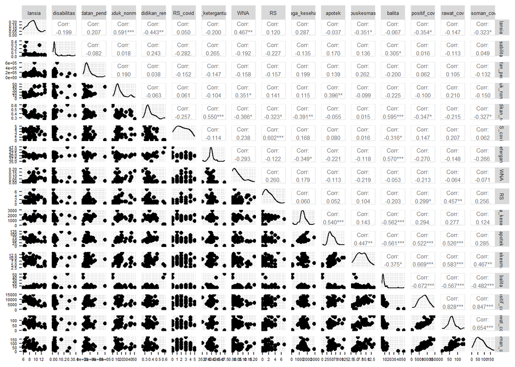

```r
ggpairs(covid[,c(2:17)], upper = list(continuous = wrap("cor", size=2)))+
  theme(axis.text = element_text(colour = "black", size = 4),
        strip.text = element_text(size = 5))
```

**Insight**: - Nilai korelasi variabel `lansia` dan `penduduk_nonmuslim` besarnya adalah 0.591. Hal ini mengindikasikan adanya hubungan yang kuat antara 2 variabel tersebut. - lansia, positif_cov dan tenaga_kesehatan cenderung memiliki distribusi normal. Variabel yang lain memiliki distribusi yg skewed

# 3 Variasi Teknik Analysis

## 3.1 Factor Analysis

> Memeriksa korelasi antar variabel

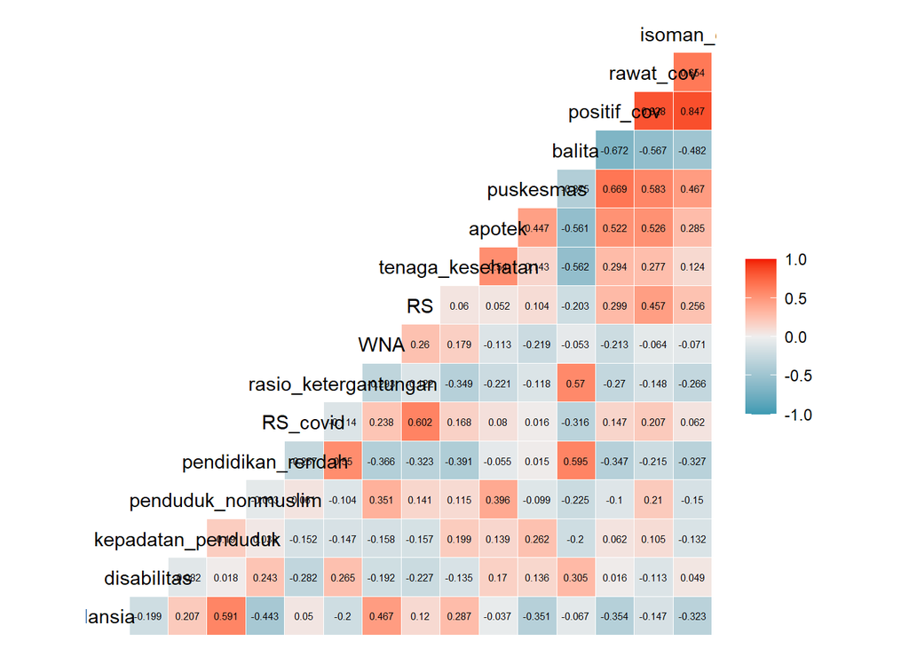

```r
ggcorr(covid, label = T, label_round = 3, label_size = 2)
```

**Insight**: Variabel-variabel yang kita punya semuanya miliki nilai korelasi (tidak ada yang tidak berhubungan) dan juga tidak ada yang melebihi 0.85 (batas atas). Sehingga asumsi multikolinearitas terpenuhi.

#### 3.1.0.1 *Kaiser–Meyer–Olkin* (KMO) - *Measure of Sampling Adequacy*(MSA)

KMO-MSA (**proporsi korelasi**) adalah uji yang dilakukan untuk menentukan kelayakan (appropriateness) dari suatu analisis faktor yang akan dilakukan.

> Skala uji KMO-MSA berkisar antara 0 sampai 1.

Jika **nilai KMO-MSA lebih rendah dari 0.5, maka analisis faktor tidak layak dilakukan**. Sedangkan jika **nilai KMO lebih besar dari 0.5, maka analisis faktor layak dilakukan**.

1. Pertama membentuk matriks korelasi dari variabel numerik pada data

```r
covid_cor <- cor(covid[,2:17])
```

2. Mencari nilai KMO-MSA dengan `KMO()` dari library `psych` menggunakan matriks korelasi yang sudah dibuat sebelumnya

```r
covid_KMO <- KMO(covid_cor)
covid_KMO
```

```
## Kaiser-Meyer-Olkin factor adequacy
## Call: KMO(r = covid_cor)
## Overall MSA =  0.56
## MSA for each item =
##               lansia          disabilitas   kepadatan_penduduk
##                 0.42                 0.33                 0.43
##   penduduk_nonmuslim    pendidikan_rendah             RS_covid
##                 0.26                 0.47                 0.57
## rasio_ketergantungan                  WNA                   RS
##                 0.78                 0.45                 0.64
##     tenaga_kesehatan               apotek            puskesmas
##                 0.44                 0.65                 0.69
##               balita          positif_cov            rawat_cov
##                 0.60                 0.69                 0.74
##           isoman_cov
##                 0.71
```

**Insight**: - Untuk nilai overall MSA : 0.56 -> data yang kita miliki sudah cukup untuk dilakukan analisis faktor

- Dari hasil output nilai MSA untuk masing-masing variabel: lansia, disabilitas, kepadatan_penduduk, penduduk_nonmuslim, pendidikan_rendah, WNA, tenaga_kesehatan memiliki besaran nilai < 0.5, tersisa RS_covid, rasio_ketergantungan, RS, apotek, puskesmas, balita, positif_cov, rawat_cov dan isoman_cov yang memiliki besaran nilai > 0.5

sehingga coba didrop MSA pada kolom-kolom yang besarannya dibawah 0.5

1.1 matriks korelasi tanpa kolom MSA yang rendah (setelah dilakukan langkah ini, RS_covid menunjukan besaran MSA dibawah 0.5 sehingga ikut didrop juga)

```r
covid_selected <- covid %>%
  select(c(rasio_ketergantungan, RS, apotek, puskesmas, balita, positif_cov, rawat_cov, isoman_cov))

covid_cor_ok <- cor(covid_selected)
```

2.1 Mencari nilai KMO-MSA

```r
covid_KMO_ok <- KMO(covid_cor_ok)
covid_KMO_ok
```

```
## Kaiser-Meyer-Olkin factor adequacy
## Call: KMO(r = covid_cor_ok)
## Overall MSA =  0.73
## MSA for each item =
## rasio_ketergantungan                   RS               apotek
##                 0.56                 0.60                 0.84
##            puskesmas               balita          positif_cov
##                 0.79                 0.72                 0.70
##            rawat_cov           isoman_cov
##                 0.83                 0.69
```

#### 3.1.0.2 *The Bartlett’s Test statistics*

Bartlett’s test digunakan untuk mengkonfirmasi bahwa data berkorelasi secara berpasangan (Mickey & Sharma, 1997). Dengan kata lain uji bartlett digunakan untuk mengetahui homogenitas variance.

- Hipotesis uji
  - H0 = Varians di antara masing-masing variabel adalah sama (variance homogen)
  - H1 = Setidaknya satu variabel memiliki varians yang tidak sama dengan yang lain (variance tidak homogen)
- Pengujian yang diharapkan adalah data memiliki variance yang tidak homogen (tolak H0).

Di R fungsi yang dapat digunakan adalah `bartlett.test()` dari base. nilai alpha = 0.05

```r
bartlett.test(covid[,c(2:17)])
```

```
##
##  Bartlett test of homogeneity of variances
##
## data:  covid[, c(2:17)]
## Bartlett's K-squared = 10804, df = 15, p-value < 2.2e-16
```

Apabila nilai p-value < alpha = tolak H0

**Insight**: Nilai p-value < 0.05/ nilai alpha. Sehingga data kita memiliki variance yang tidak homogen/ berbeda satu sama lainnya.